# Serie de tiempo cáncer de Vejiga en Antofagasta

#### Variables en la base de datos.

- TUMOURID: Identificación del tumor.
- NOCASO: Número del caso (1 caso puede tener uno o más tumores).
- FECNAC: Fecha nacimiento en formato YYYYMMDD (variable numérica).
- EDAD: Edad en años a la fecha del diagnóstico.
- SEXO:
  - 1=Hombre,
  - 2=Mujeres.
- REGCOM: Código comunas:
  - 2101=Antofagasta;
  - 2201=Calama;
  - 2301=Tocopilla.
- FECDIAG: Fecha de diagnóstico del tumor en formato YYYYMMDD (variable numérica), “20030101 - 20151231”.
- TOP: Código topográfico del tumor en formato CIE-O.
- MORF: Código morfológico CIE-O.
- MORF_GRUPO (VEJIGA):
  - 1=Neoplasias, SAI;
  - 2=Carcinomas de células transicionales;
  - 3=Otras Morfologías
- COMP: Comportamiento del tumor:
  - 3=Maligno.
- GRA: Grado de diferenciación del tumor:
  - 1=Bien diferenciado;
  - 2= Moderadamente Diferenciado;
  - 3=Poco Diferenciado;
  - 4=Anaplásico;
  - 5=Células T;
  - 6=Células B;
  - 7=Célula Nula;
  - 8=Células NK;
  - 9=Desconocido.
- EXT: Grado de extensión del tumor:
  - 0=In situ;
  - 1=Localizado;
  - 2=Regional;
  - 3=Metástasis;
  - 9=Desconocido.
- BASE: Base diagnóstico:
  - 0=Solo Certificado de defunción;
  - 1=Clínico;
  - 2=Investigación clínica;
  - 4=Bioquímica o Inmunología;
  - 5=Citología;
  - 6=Histología de metástasis;
  - 7=Histología de sitio primario;
  - 9=Desconocido.
- C10: Código CIE10.
- PMSEC: Secuencia de tumores primarios.
- PMTOT: Número total de tumores primarios.
- FUE1: Fuente.
- RUT: Rut del caso.

# Estadística descriptiva

## Univariada categórica para tumores de Vejiga

### Número de casos por sexo

```
##
## Hombres Mujeres
##     595     323
```

### Proporción de casos por sexo

```
##
## Hombres Mujeres
##   64.81   35.19
```

### Casos por comuna

```
##
##                 Afta           Mejillones         Sierra Gorda
##                  695                   10                    3
##               Taltal               Calama              Ollagüe
##                   10                  111                    0
## San Pedro de Atacama            Tocopilla          MAría Elena
##                    1                   75                   13
##                  Sum
##                  918
```

### Proporción de casos por comuna

```
##
##                 Afta           Mejillones         Sierra Gorda
##                   76                    1                    0
##               Taltal               Calama              Ollagüe
##                    1                   12                    0
## San Pedro de Atacama            Tocopilla          MAría Elena
##                    0                    8                    1
```

### Casos en Antofagasta, Calama y Tocopilla

```
##
##      Afta    Calama Tocopilla
##       695       111        75
```

### Proporción de casos en Antofagasta, Calama y Tocopilla

```
##
##      Afta    Calama Tocopilla
##     78.89     12.60      8.51
```

### Casos según morfología

```
##
##                      Neoplasias, SAI Carcinomas de células transicionales
##                                  167                                  683
##                    Otras morfologías
##                                   68
```

### Proporción de casos según morfología

```
##
##                      Neoplasias, SAI Carcinomas de células transicionales
##                                 18.2                                 74.4
##                    Otras morfologías
##                                  7.4
```

### Casos según diferenciacion tumores

```
##
##           Bien Diferenciado Moderadamente Diferenciados
##                          89                          63
##           Poco Diferenciado                  Anaplásico
##                         234                           5
##                 Desconocido
##                         527
```

### Proporción de casos según diferenciación

```
##
##           Bien Diferenciado Moderadamente Diferenciados
##                        9.69                        6.86
##           Poco Diferenciado                  Anaplásico
##                       25.49                        0.54
##                 Desconocido
##                       57.41
```

### Casos según extensión tumoral

```
##
##  Localizado    Regional  Metástasis Desconocido
##         660          82          84          92
```

### Proporción de casos según extensión tumoral

```
##
##  Localizado    Regional  Metástasis Desconocido
##       71.90        8.93        9.15       10.02
```

### Casos según base diagnóstico

```
##
##                     Solo DCO                      Clínica
##                           75                           24
##        Investigación Clínica            Histología de MTS
##                           64                           11
## Histología de sitio primario
##                          744
```

### Proporción de casos según base diagnóstico

```
##
##                     Solo DCO                      Clínica
##                         8.17                         2.61
##        Investigación Clínica            Histología de MTS
##                         6.97                         1.20
## Histología de sitio primario
##                        81.05
```

## Estadística descriptiva univariada cuantitativa, Vejiga

### Edad

| Mínimo | Máximo | Rango | Qu_25 | Qu_50 | Qu_75 | Media | Mediana | Varianza | Desv_Estándar | CV |
| --- | --- | --- | --- | --- | --- | --- | --- | --- | --- | --- |
| 20 | 97 | 77 | 58 | 67 | 76 | 66.6013 | 67 | 153.6446 | 12.3953 | 18.6113 |

### Histrograma edad

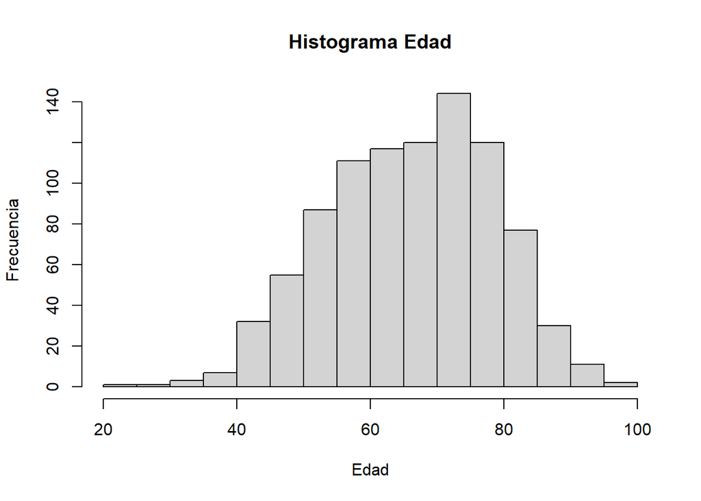

### Gráfico de densidad edad

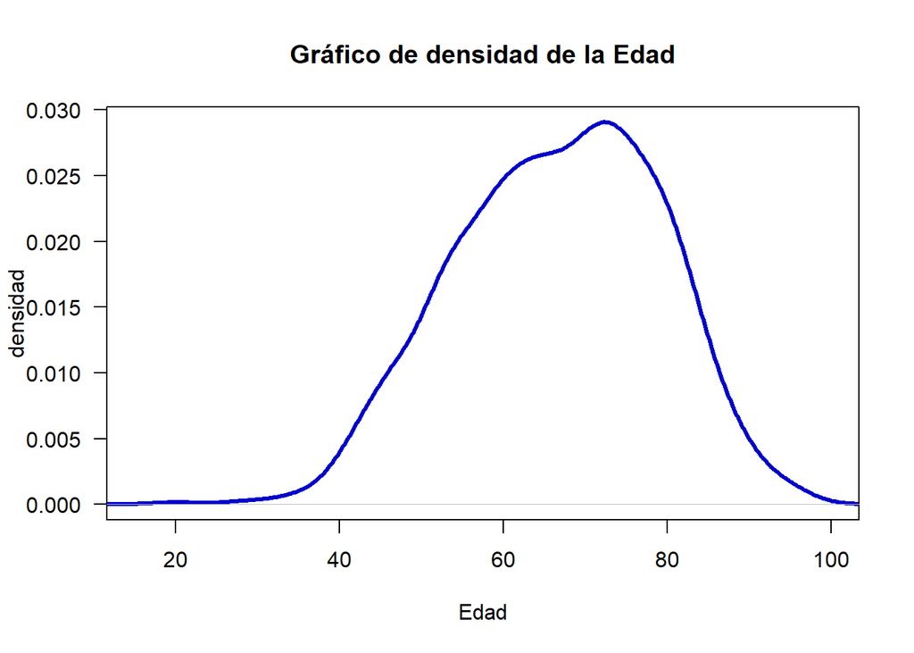

### Normal QQ

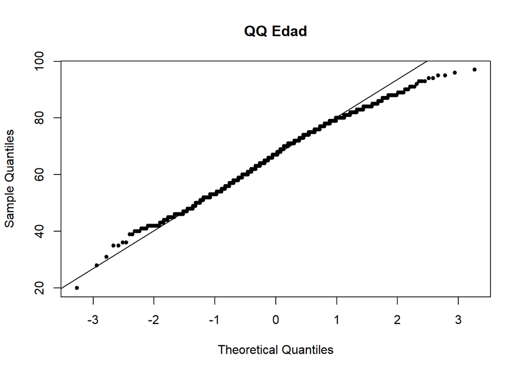

### Test de normalidad de Shapiro-Wilk

```
##
##  Shapiro-Wilk normality test
##
## data:  bd_$EDAD
## W = 0.99101, p-value = 2.149e-05
```

## Estadística descriptiva Bivariada

### Número de casos por sexo en las comunas de Antofagasta, Calama y Tocopilla

```
##
##               Hombres Mujeres Sum
##   Antofagasta     442     253 695
##   Calama           81      30 111
##   Tocopilla        45      30  75
##   Sum             568     313 881
```

### Proporción de casos por sexo en las comunas de Antofagasta, Calama y Tocopilla

```
##
##               Hombres Mujeres    Sum
##   Antofagasta   63.60   36.40 100.00
##   Calama        72.97   27.03 100.00
##   Tocopilla     60.00   40.00 100.00
```

### Número de casos por sexo y morfología

```
##
##                                        Hombres Mujeres Sum
##   Neoplasias, SAI                           99      68 167
##   Carcinomas de células transicionales     455     228 683
##   Otras morfologías                         41      27  68
##   Sum                                      595     323 918
```

### Proporción de casos por sexo y morfología

```
##
##                                        Hombres Mujeres    Sum
##   Neoplasias, SAI                        59.28   40.72 100.00
##   Carcinomas de células transicionales   66.62   33.38 100.00
##   Otras morfologías                      60.29   39.71 100.00
```

### Número de casos por sexo y extensión tumoral

```
##
##               Hombres Mujeres Sum
##   Localizado      436     224 660
##   Regional         54      28  82
##   Metástasis       50      34  84
##   Desconocido      55      37  92
##   Sum             595     323 918
```

### Proporción de casos por sexo y extensión tumoral

```
##
##               Hombres Mujeres    Sum
##   Localizado    66.06   33.94 100.00
##   Regional      65.85   34.15 100.00
##   Metástasis    59.52   40.48 100.00
##   Desconocido   59.78   40.22 100.00
```

### Número de casos por sexo y base diagnóstica

```
##
##                                Hombres Mujeres Sum
##   Solo DCO                          45      30  75
##   Clínico                           14      10  24
##   Investigación Clínica             37      27  64
##   Histología de Metástasis           6       5  11
##   Histología de sitio primario     493     251 744
##   Sum                              595     323 918
```

### Proporción de casos por sexo y base diagnóstica

```
##
##                                Hombres Mujeres    Sum
##   Solo DCO                       60.00   40.00 100.00
##   Clínico                        58.33   41.67 100.00
##   Investigación Clínica          57.81   42.19 100.00
##   Histología de Metástasis       54.55   45.45 100.00
##   Histología de sitio primario   66.26   33.74 100.00
```

### Número de casos por Morfología y base diagnóstica

```
##
##                                        Solo DCO Clínico Investigación Clínica
##   Neoplasias, SAI                            75      24                    64
##   Carcinomas de células transicionales        0       0                     0
##   Otras morfologías                           0       0                     0
##   Sum                                        75      24                    64
##
##                                        Histología de Metástasis
##   Neoplasias, SAI                                             0
##   Carcinomas de células transicionales                        8
##   Otras morfologías                                           3
##   Sum                                                        11
##
##                                        Histología de sitio primario Sum
##   Neoplasias, SAI                                                 4 167
##   Carcinomas de células transicionales                          675 683
##   Otras morfologías                                              65  68
##   Sum                                                           744 918
```

### Proporción de casos por Morfología y base diagnóstica

```
##
##                                        Solo DCO Clínico Investigación Clínica
##   Neoplasias, SAI                         44.91   14.37                 38.32
##   Carcinomas de células transicionales     0.00    0.00                  0.00
##   Otras morfologías                        0.00    0.00                  0.00
##
##                                        Histología de Metástasis
##   Neoplasias, SAI                                          0.00
##   Carcinomas de células transicionales                     1.17
##   Otras morfologías                                        4.41
##
##                                        Histología de sitio primario    Sum
##   Neoplasias, SAI                                              2.40 100.00
##   Carcinomas de células transicionales                        98.83 100.00
##   Otras morfologías                                           95.59 100.00
```

### Número de casos por Morfología y Extensión

```
##
##                                        Localizado Regional Metástasis
##   Neoplasias, SAI                              34       11         41
##   Carcinomas de células transicionales        576       63         35
##   Otras morfologías                            50        8          8
##   Sum                                         660       82         84
##
##                                        Desconocido Sum
##   Neoplasias, SAI                               81 167
##   Carcinomas de células transicionales           9 683
##   Otras morfologías                              2  68
##   Sum                                           92 918
```

### Proporción de casos por Morfología y Extensión

```
##
##                                        Localizado Regional Metástasis
##   Neoplasias, SAI                           20.36     6.59      24.55
##   Carcinomas de células transicionales      84.33     9.22       5.12
##   Otras morfologías                         73.53    11.76      11.76
##
##                                        Desconocido    Sum
##   Neoplasias, SAI                            48.50 100.00
##   Carcinomas de células transicionales        1.32 100.00
##   Otras morfologías                           2.94 100.00
```

### Número de casos por Morfología y comuna

```
##
##                                        Antofagasta Calama Tocopilla Sum
##   Neoplasias, SAI                              117     25        20 162
##   Carcinomas de células transicionales         531     70        53 654
##   Otras morfologías                             47     16         2  65
##   Sum                                          695    111        75 881
```

### Proporción de casos por Morfología y comuna, por filas

```
##
##                                        Antofagasta Calama Tocopilla    Sum
##   Neoplasias, SAI                            72.22  15.43     12.35 100.00
##   Carcinomas de células transicionales       81.19  10.70      8.10 100.00
##   Otras morfologías                          72.31  24.62      3.08 100.00
```

### Proporción de casos por Morfología y comuna, por columnas

```
##
##                                        Antofagasta Calama Tocopilla
##   Neoplasias, SAI                            16.83  22.52     26.67
##   Carcinomas de células transicionales       76.40  63.06     70.67
##   Otras morfologías                           6.76  14.41      2.67
##   Sum                                       100.00 100.00    100.00
```

### Número de casos por Extensión y comuna

```
##
##               Antofagasta Calama Tocopilla Sum
##   Localizado          509     73        50 632
##   Regional             64      8         3  75
##   Metástasis           58     17         8  83
##   Desconocido          64     13        14  91
##   Sum                 695    111        75 881
```

### Proporcion de casos por Extensión y comuna, filas

```
##
##               Antofagasta Calama Tocopilla    Sum
##   Localizado        80.54  11.55      7.91 100.00
##   Regional          85.33  10.67      4.00 100.00
##   Metástasis        69.88  20.48      9.64 100.00
##   Desconocido       70.33  14.29     15.38 100.00
```

### Proporción de casos por Extensión y comuna, columnas

```
##
##               Antofagasta Calama Tocopilla
##   Localizado        73.24  65.77     66.67
##   Regional           9.21   7.21      4.00
##   Metástasis         8.35  15.32     10.67
##   Desconocido        9.21  11.71     18.67
##   Sum              100.00 100.00    100.00
```

### Número de casos por Extensión y Base diagnóstica

```
##
##               Solo DCO Clínico Investigación Clínica Histología de Metástasis
##   Localizado         2      18                    12                        3
##   Regional           0       1                    10                        0
##   Metástasis         3       2                    35                        8
##   Desconocido       70       3                     7                        0
##   Sum               75      24                    64                       11
##
##               Histología de sitio primario Sum
##   Localizado                           625 660
##   Regional                              71  82
##   Metástasis                            36  84
##   Desconocido                           12  92
##   Sum                                  744 918
```

### Proporción de casos por Extensión y Base diagnóstica, filas

```
##
##               Solo DCO Clínico Investigación Clínica Histología de Metástasis
##   Localizado      0.30    2.73                  1.82                     0.45
##   Regional        0.00    1.22                 12.20                     0.00
##   Metástasis      3.57    2.38                 41.67                     9.52
##   Desconocido    76.09    3.26                  7.61                     0.00
##
##               Histología de sitio primario    Sum
##   Localizado                         94.70 100.00
##   Regional                           86.59 100.00
##   Metástasis                         42.86 100.00
##   Desconocido                        13.04 100.00
```

### Proporción de casos por Extensión y Base diagnóstica, columnas

```
##
##               Solo DCO Clínico Investigación Clínica Histología de Metástasis
##   Localizado      2.67   75.00                 18.75                    27.27
##   Regional        0.00    4.17                 15.62                     0.00
##   Metástasis      4.00    8.33                 54.69                    72.73
##   Desconocido    93.33   12.50                 10.94                     0.00
##   Sum           100.00  100.00                100.00                   100.00
##
##               Histología de sitio primario
##   Localizado                         84.01
##   Regional                            9.54
##   Metástasis                          4.84
##   Desconocido                         1.61
##   Sum                               100.00
```

### Número de casos por Base diagnóstica y comuna

```
##
##                                Antofagasta Calama Tocopilla Sum
##   Solo DCO                              55     10         9  74
##   Clínico                               16      3         4  23
##   Investigación Clínica                 44     10         7  61
##   Histología de Metástasis               8      2         1  11
##   Histología de sitio primario         572     86        54 712
##   Sum                                  695    111        75 881
```

### Proporción de casos por Base diagnóstica y comuna, filas

```
##
##                                Antofagasta Calama Tocopilla    Sum
##   Solo DCO                           74.32  13.51     12.16 100.00
##   Clínico                            69.57  13.04     17.39 100.00
##   Investigación Clínica              72.13  16.39     11.48 100.00
##   Histología de Metástasis           72.73  18.18      9.09 100.00
##   Histología de sitio primario       80.34  12.08      7.58 100.00
```

### Proporción de casos por Base diagnóstica y comuna, columnas

```
##
##                                Antofagasta Calama Tocopilla
##   Solo DCO                            7.91   9.01     12.00
##   Clínico                             2.30   2.70      5.33
##   Investigación Clínica               6.33   9.01      9.33
##   Histología de Metástasis            1.15   1.80      1.33
##   Histología de sitio primario       82.30  77.48     72.00
##   Sum                               100.00 100.00    100.00
```

### Edad - Sexo

#### Boxplot edad vs sexo

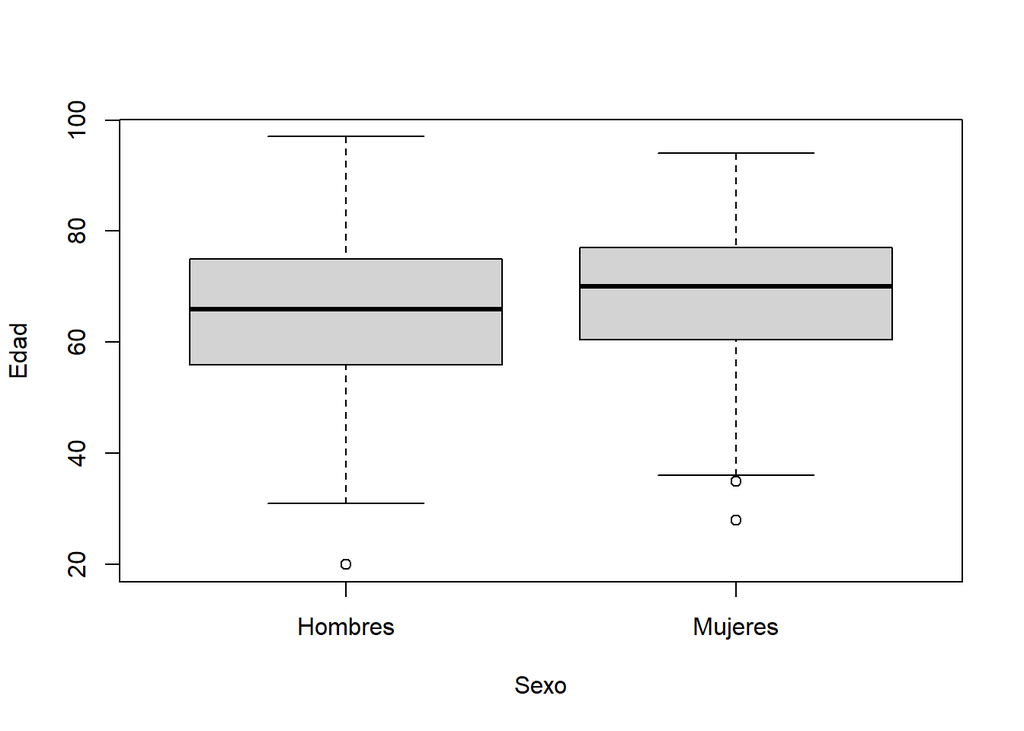

### Boxplot edad vs comuna

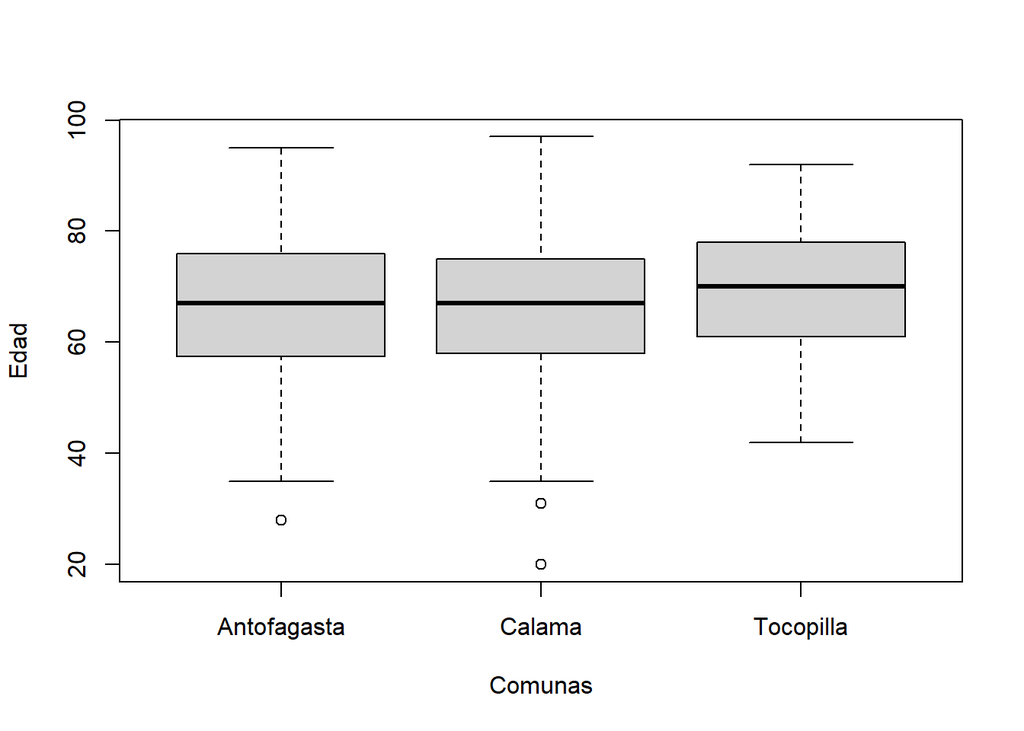

### Boxplot edad - morfologia

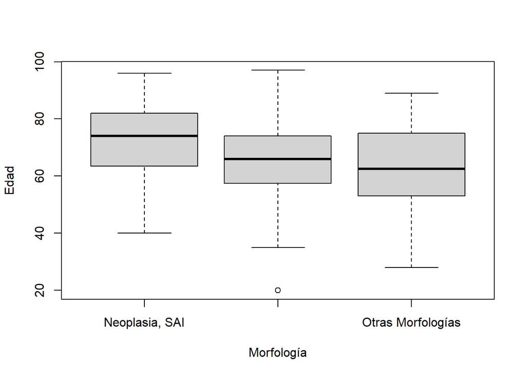

### Boxplot edad - extension

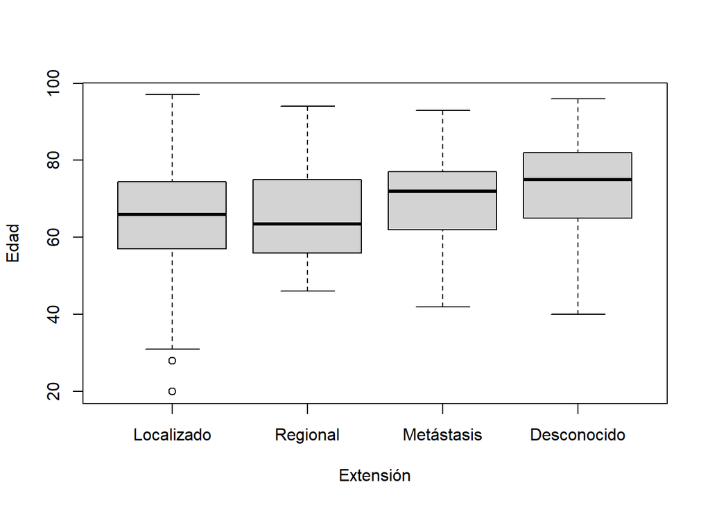

### Boxplot edad - base diagnóstica

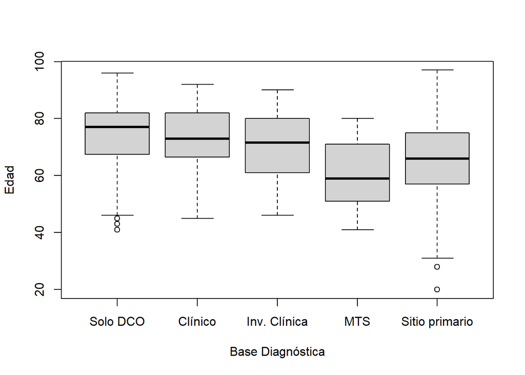

## Tasa de incidencia ajustada por año

| YEAR_DIAG | TASA_AJUSTADA |
| --- | --- |
| 2003 | 11.414171 |
| 2004 | 13.897391 |
| 2005 | 10.776012 |
| 2006 | 17.195132 |
| 2007 | 12.055086 |
| 2008 | 16.108703 |
| 2009 | 15.008298 |
| 2010 | 10.935358 |
| 2011 | 12.247321 |
| 2012 | 11.531715 |

[output cut: 3 more lines]

### Gráfico de la tasa de incidencia de cáncer de Vejiga, ajustada por edad en la región de Antofagasta.

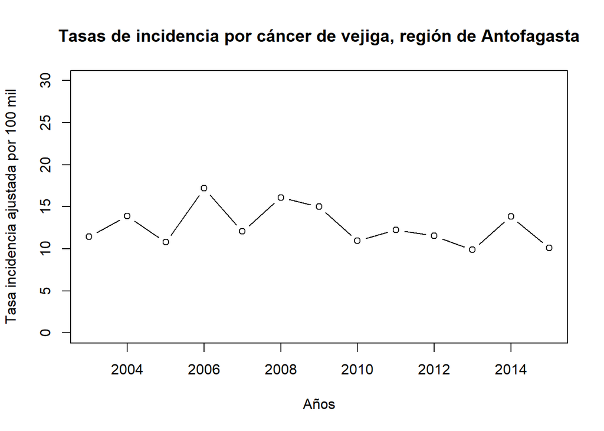

## Tasa de incidencia ajustada por edad y sexo, según año. Región de Antofagasta

| YEAR_DIAG | TASA_AJUSTADA | STD_ERROR |
| --- | --- | --- |
| 2003 | 8.054627 | 1.3515920 |
| 2004 | 8.016225 | 1.3264796 |
| 2005 | 5.503270 | 1.0596334 |
| 2006 | 10.165936 | 1.4303016 |
| 2007 | 7.230132 | 1.2067091 |
| 2008 | 11.240772 | 1.5012973 |
| 2009 | 9.646323 | 1.3736392 |
| 2010 | 8.042997 | 1.2395681 |
| 2011 | 7.730491 | 1.1944853 |
| 2012 | 7.383668 | 1.0792974 |

[output cut: 3 more lines]

| YEAR_DIAG | TASA_AJUSTADA | STD_ERROR |
| --- | --- | --- |
| 2003 | 3.359543 | 0.8829744 |
| 2004 | 5.881166 | 1.1516060 |
| 2005 | 5.272742 | 1.0797736 |
| 2006 | 7.029195 | 1.2154970 |
| 2007 | 4.824954 | 0.9692072 |
| 2008 | 4.867931 | 1.0028582 |
| 2009 | 5.361975 | 0.9921065 |
| 2010 | 2.892361 | 0.7248754 |
| 2011 | 4.516830 | 0.8948217 |
| 2012 | 4.148048 | 0.8317816 |

[output cut: 3 more lines]

### Gráfico de la tasa de incidencia de cáncer de vejiga, ajustada por edad y sexo en la región de Antofagasta.

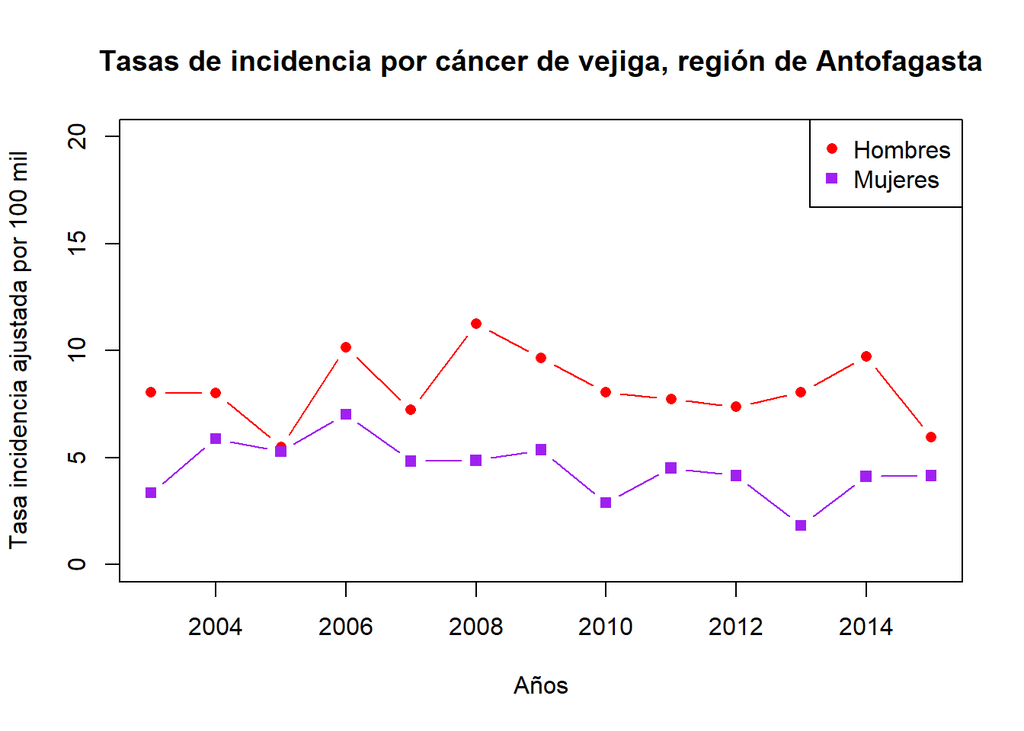

# Comuna de Antofagasta

### Número de casos por sexo, Comuna de Antofagasta

```
##
## Hombres Mujeres
##     442     253
```

### Proporción de casos por sexo, comuna de Antofagastas

```
##
## Hombres Mujeres
##    63.6    36.4
```

### Casos según morfología, comuna de Antofagasta

```
##
##                      Neoplasias, SAI Carcinomas de células transicionales
##                                  117                                  531
##                    Otras morfologías
##                                   47
```

### Proporción de casos según morfología, comuna de Antofagasta

```
##
##                      Neoplasias, SAI Carcinomas de células transicionales
##                                 16.8                                 76.4
##                    Otras morfologías
##                                  6.8
```

### Casos según diferenciacion tumores, comuna de Antofagasta

```
##
##           Bien Diferenciado Moderadamente Diferenciados
##                          68                          52
##           Poco Diferenciado                  Anaplásico
##                         180                           2
##                 Desconocido
##                         393
```

### Proporción de casos según diferenciación, Comuna de Antofagasta

```
##
##           Bien Diferenciado Moderadamente Diferenciados
##                        9.78                        7.48
##           Poco Diferenciado                  Anaplásico
##                       25.90                        0.29
##                 Desconocido
##                       56.55
```

### Casos según extensión tumoral, Comuna de Antofagasta

```
##
##  Localizado    Regional  Metástasis Desconocido
##         509          64          58          64
```

### Proporción de casos según extensión tumoral, Comuna de Antofagasta

```
##
##  Localizado    Regional  Metástasis Desconocido
##       73.24        9.21        8.35        9.21
```

### Casos según base diagnóstico, Comuna de Antofagasta

```
##
##                     Solo DCO                      Clínica
##                           55                           16
##        Investigación Clínica            Histología de MTS
##                           44                            8
## Histología de sitio primario
##                          572
```

### Proporción de casos según base diagnóstico, Comuna de Antofagasta

```
##
##                     Solo DCO                      Clínica
##                         7.91                         2.30
##        Investigación Clínica            Histología de MTS
##                         6.33                         1.15
## Histología de sitio primario
##                        82.30
```

## Estadística descriptiva univariada cuantitativa, Vejiga Comuna de Antofagasta

### Edad, Comuna de Antofagasta

| Mínimo | Máximo | Rango | Qu_25 | Qu_50 | Qu_75 | Media | Mediana | Varianza | Desv_Estándar | CV |
| --- | --- | --- | --- | --- | --- | --- | --- | --- | --- | --- |
| 28 | 95 | 67 | 57.5 | 67 | 76 | 66.5281 | 67 | 155.5176 | 12.4707 | 18.745 |

### Histrograma edad, Comuna de Antofagasta

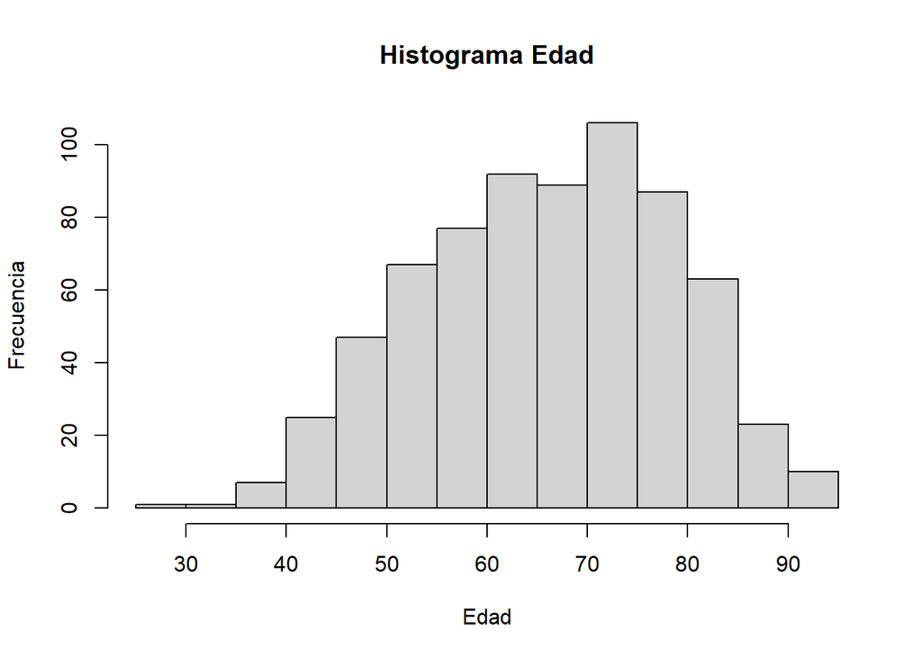

### Gráfico de densidad edad, Comuna de Antofagasta

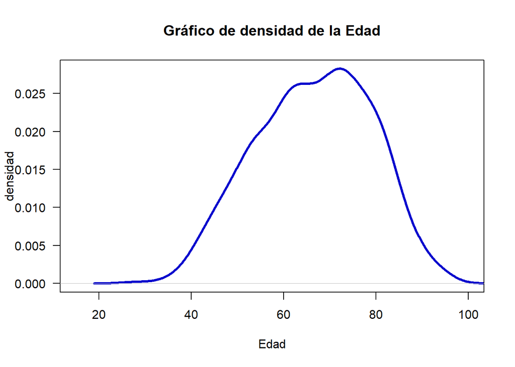

### Normal QQ, Comuna de Antofagasta

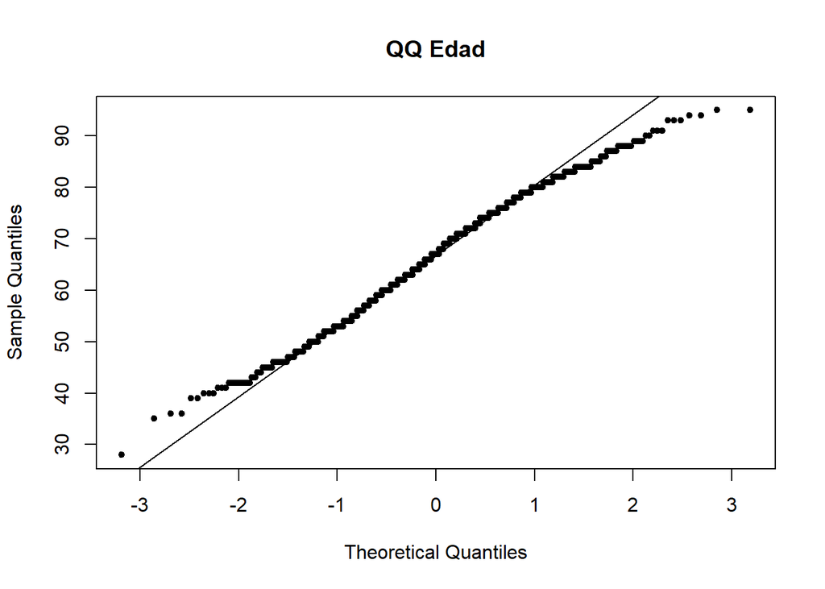

### Test de normalidad de Shapiro-Wilk, Comuna de Antofagasta

```
##
##  Shapiro-Wilk normality test
##
## data:  bd_1$EDAD
## W = 0.98906, p-value = 4.724e-05
```

## Estadística descriptiva Bivariada, comuna de Antofagasta

### Número de casos por sexo y morfología, comuna de Antofagasta

```
##
##                                        Hombres Mujeres Sum
##   Neoplasias, SAI                           70      47 117
##   Carcinomas de células transicionales     346     185 531
##   Otras morfologías                         26      21  47
##   Sum                                      442     253 695
```

### Proporción de casos por sexo y morfología, comuna de Antofagasta

```
##
##                                        Hombres Mujeres    Sum
##   Neoplasias, SAI                        59.83   40.17 100.00
##   Carcinomas de células transicionales   65.16   34.84 100.00
##   Otras morfologías                      55.32   44.68 100.00
```

### Número de casos por sexo y extensión tumoral, comuna de Antofagasta

```
##
##               Hombres Mujeres Sum
##   Localizado      331     178 509
##   Regional         41      23  64
##   Metástasis       33      25  58
##   Desconocido      37      27  64
##   Sum             442     253 695
```

### Proporción de casos por sexo y extensión tumoral, Comuna de Antofagasta

```
##
##               Hombres Mujeres    Sum
##   Localizado    65.03   34.97 100.00
##   Regional      64.06   35.94 100.00
##   Metástasis    56.90   43.10 100.00
##   Desconocido   57.81   42.19 100.00
```

### Número de casos por sexo y base diagnóstica, comuna de Antofagasta

```
##
##                                Hombres Mujeres Sum
##   Solo DCO                          34      21  55
##   Clínico                           10       6  16
##   Investigación Clínica             25      19  44
##   Histología de Metástasis           5       3   8
##   Histología de sitio primario     368     204 572
##   Sum                              442     253 695
```

### Proporción de casos por sexo y base diagnóstica, comuna de Antofagasta

```
##
##                                Hombres Mujeres    Sum
##   Solo DCO                       61.82   38.18 100.00
##   Clínico                        62.50   37.50 100.00
##   Investigación Clínica          56.82   43.18 100.00
##   Histología de Metástasis       62.50   37.50 100.00
##   Histología de sitio primario   64.34   35.66 100.00
```

### Número de casos por Morfología y base diagnóstica, comuna de Antofagasta

```
##
##                                       Solo DCO Clínico Investigación Clínica
##   Neoplasias, SAI                           55      16                    44
##   Carcinoma de células transicionales        0       0                     0
##   Otras morfologías                          0       0                     0
##   Sum                                       55      16                    44
##
##                                       Histología de Metástasis
##   Neoplasias, SAI                                            0
##   Carcinoma de células transicionales                        7
##   Otras morfologías                                          1
##   Sum                                                        8
##
##                                       Histología de sitio primario Sum
##   Neoplasias, SAI                                                2 117
##   Carcinoma de células transicionales                          524 531
##   Otras morfologías                                             46  47
##   Sum                                                          572 695
```

### Proporción de casos por Morfología y base diagnóstica, comuna de Antofagasta

```
##
##                                       Solo DCO Clínico Investigación Clínica
##   Neoplasias, SAI                        47.01   13.68                 37.61
##   Carcinoma de células transicionales     0.00    0.00                  0.00
##   Otras morfologías                       0.00    0.00                  0.00
##
##                                       Histología de Metástasis
##   Neoplasias, SAI                                         0.00
##   Carcinoma de células transicionales                     1.32
##   Otras morfologías                                       2.13
##
##                                       Histología de sitio primario    Sum
##   Neoplasias, SAI                                             1.71 100.00
##   Carcinoma de células transicionales                        98.68 100.00
##   Otras morfologías                                          97.87 100.00
```

### Número de casos por Morfología y Extensión, comuna de Antofagasta

```
##
##                                       Localizado Regional Metástasis
##   Neoplasias, SAI                             25        8         26
##   Carcinoma de células transicionales        446       52         28
##   Otras morfologías                           38        4          4
##   Sum                                        509       64         58
##
##                                       Desconocido Sum
##   Neoplasias, SAI                              58 117
##   Carcinoma de células transicionales           5 531
##   Otras morfologías                             1  47
##   Sum                                          64 695
```

### Proporción de casos por Morfología y Extensión, comuna de Antofagasta

```
##
##                                       Localizado Regional Metástasis
##   Neoplasias, SAI                          21.37     6.84      22.22
##   Carcinoma de células transicionales      83.99     9.79       5.27
##   Otras morfologías                        80.85     8.51       8.51
##
##                                       Desconocido    Sum
##   Neoplasias, SAI                           49.57 100.00
##   Carcinoma de células transicionales        0.94 100.00
##   Otras morfologías                          2.13 100.00
```

### Número de casos por Extensión y Base diagnóstica, comuna de Antofagasta

```
##
##               Solo DCO Clínico Investigación Clínica Histología de Metástasis
##   Localizado         1      12                    11                        2
##   Regional           0       1                     7                        0
##   Metástasis         3       2                    21                        6
##   Desconocido       51       1                     5                        0
##   Sum               55      16                    44                        8
##
##               Histología de sitio primario Sum
##   Localizado                           483 509
##   Regional                              56  64
##   Metástasis                            26  58
##   Desconocido                            7  64
##   Sum                                  572 695
```

### Proporción de casos por Extensión y Base diagnóstica, filas, comuna de Antofagastas

```
##
##               Solo DCO Clínico Investigación Clínica Histología de Metástasis
##   Localizado      0.20    2.36                  2.16                     0.39
##   Regional        0.00    1.56                 10.94                     0.00
##   Metástasis      5.17    3.45                 36.21                    10.34
##   Desconocido    79.69    1.56                  7.81                     0.00
##
##               Histología de sitio primario    Sum
##   Localizado                         94.89 100.00
##   Regional                           87.50 100.00
##   Metástasis                         44.83 100.00
##   Desconocido                        10.94 100.00
```

### Proporción de casos por Extensión y Base diagnóstica, columnas, Comuna de Antofagasta

```
##
##               Solo DCO Clínico Investigación Clínica Histología de Metástasis
##   Localizado      1.82   75.00                 25.00                    25.00
##   Regional        0.00    6.25                 15.91                     0.00
##   Metástasis      5.45   12.50                 47.73                    75.00
##   Desconocido    92.73    6.25                 11.36                     0.00
##   Sum           100.00  100.00                100.00                   100.00
##
##               Histología de sitio primario
##   Localizado                         84.44
##   Regional                            9.79
##   Metástasis                          4.55
##   Desconocido                         1.22
##   Sum                               100.00
```

### Edad - Sexo

#### Boxplot edad vs sexo, Comuna de Antofagasta

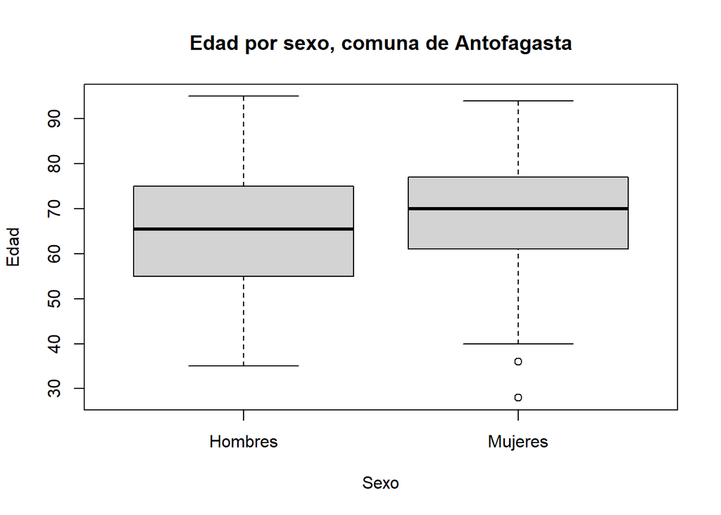

### Boxplot edad - morfologia, Comuna de Antofagasta

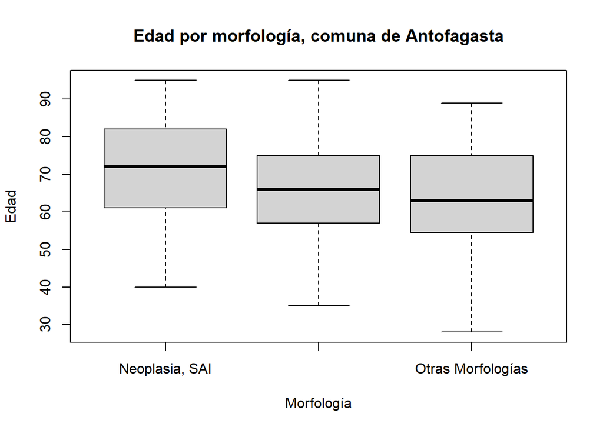

### Boxplot edad - extension, Comuna de Antofagasta

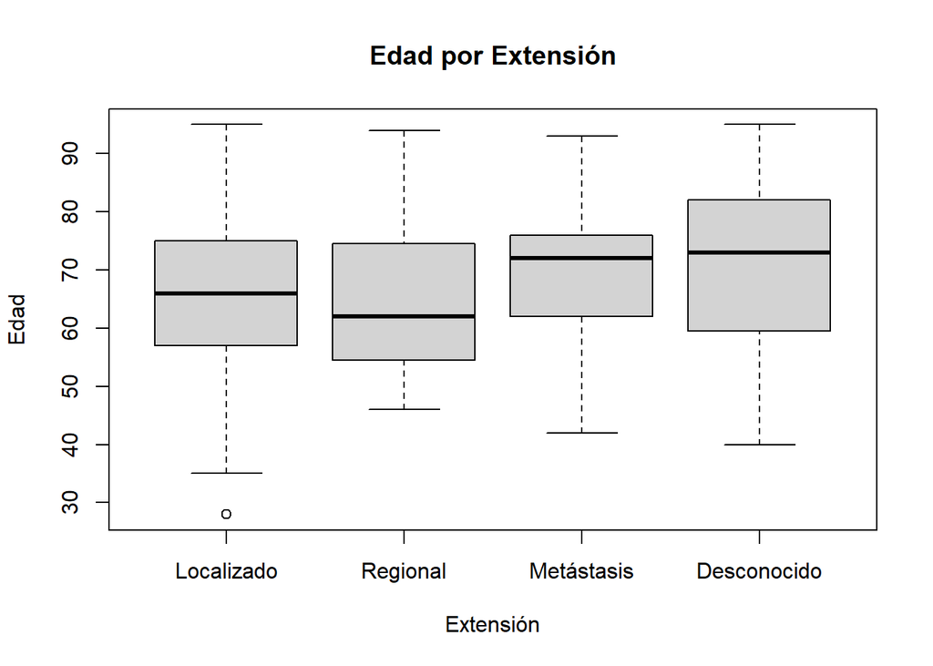

### Boxplot edad - base diagnóstica, Comuna de Antofagasta

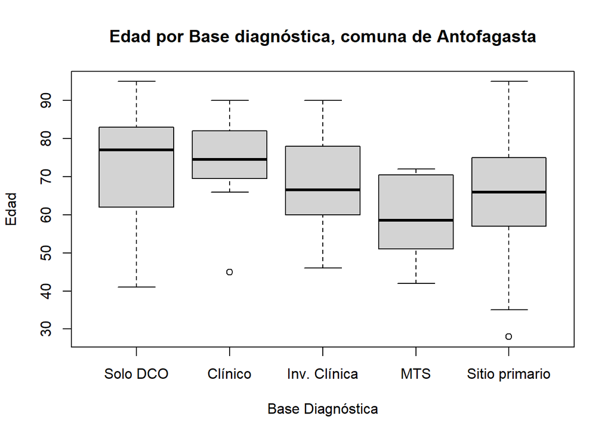

## Tasa de incidencia ajustada por año, Comuna de Antofagasta

| YEAR_DIAG | TASA_AJUSTADA |
| --- | --- |
| 2003 | 14.96648 |
| 2004 | 16.71434 |
| 2005 | 14.78442 |
| 2006 | 20.20424 |
| 2007 | 14.95171 |
| 2008 | 19.17858 |
| 2009 | 16.24129 |
| 2010 | 12.28889 |
| 2011 | 15.53056 |
| 2012 | 13.63177 |

[output cut: 3 more lines]

### Gráfico de la tasa de incidencia de cáncer de vejiga, ajustada por edad en Comuna de Antofagasta

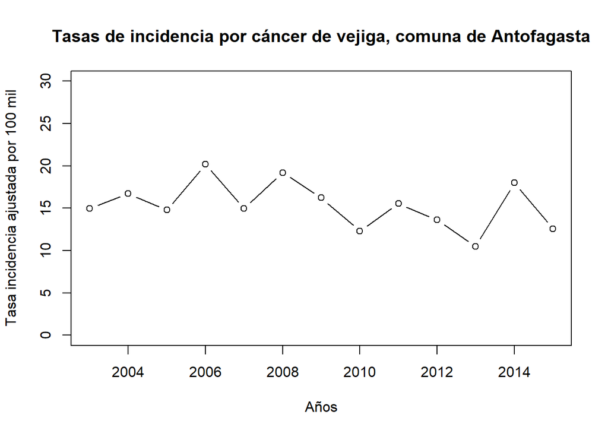

## Tasa de incidencia ajustada por edad y sexo, según año. Comuna de Antofagasta

| YEAR_DIAG | TASA_AJUSTADA | STD_ERROR |
| --- | --- | --- |
| 2003 | 9.948571 | 1.887510 |
| 2004 | 9.668040 | 1.800789 |
| 2005 | 7.412974 | 1.536899 |
| 2006 | 11.694042 | 1.968459 |
| 2007 | 8.573057 | 1.644339 |
| 2008 | 12.553241 | 2.014469 |
| 2009 | 10.378011 | 1.804055 |
| 2010 | 10.125901 | 1.749679 |
| 2011 | 9.674104 | 1.679214 |
| 2012 | 8.005809 | 1.427099 |

[output cut: 3 more lines]

| YEAR_DIAG | TASA_AJUSTADA | STD_ERROR |
| --- | --- | --- |
| 2003 | 5.017914 | 1.3637942 |
| 2004 | 7.046299 | 1.6047833 |
| 2005 | 7.371444 | 1.6090469 |
| 2006 | 8.510198 | 1.6777335 |
| 2007 | 6.378655 | 1.3914183 |
| 2008 | 6.625334 | 1.4903585 |
| 2009 | 5.863279 | 1.2876789 |
| 2010 | 2.162992 | 0.7965146 |
| 2011 | 5.856457 | 1.2866353 |
| 2012 | 5.625956 | 1.2287912 |

[output cut: 3 more lines]

### Gráfico de la tasa de incidencia de cáncer de Vejiga, ajustada por edad y sexo en la comuna de Antofagasta.

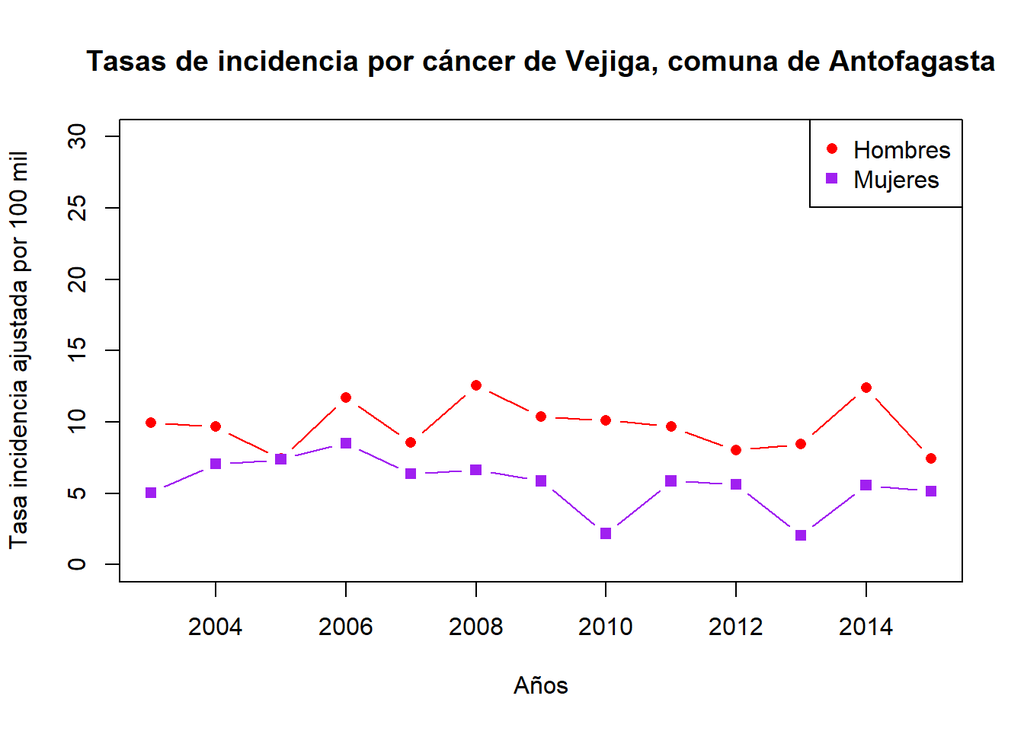

# Comuna de Calama

### Número de casos por sexo, Comuna de Calama

```
##
## Hombres Mujeres
##      81      30
```

### Proporción de casos por sexo, comuna de Calama

```
##
## Hombres Mujeres
##   72.97   27.03
```

### Casos según morfología, comuna de Calama

```
##
##                      Neoplasias, SAI Carcinomas de células transicionales
##                                   25                                   70
##                    Otras morfologías
##                                   16
```

### Proporción de casos según morfología, comuna de Calama

```
##
##                      Neoplasias, SAI Carcinomas de células transicionales
##                                 22.5                                 63.1
##                    Otras morfologías
##                                 14.4
```

### Casos según diferenciacion tumores, comuna de Calama

```
##
##           Bien Diferenciado Moderadamente Diferenciados
##                          11                           7
##           Poco Diferenciado                  Anaplásico
##                          28                           1
##                 Desconocido
##                          64
```

### Proporción de casos según diferenciación, Comuna de Calama

```
##
##           Bien Diferenciado Moderadamente Diferenciados
##                        9.91                        6.31
##           Poco Diferenciado                  Anaplásico
##                       25.23                        0.90
##                 Desconocido
##                       57.66
```

### Casos según extensión tumoral, Comuna de Calama

```
##
##  Localizado    Regional  Metástasis Desconocido
##          73           8          17          13
```

### Proporción de casos según extensión tumoral, Comuna de Calama

```
##
##  Localizado    Regional  Metástasis Desconocido
##       65.77        7.21       15.32       11.71
```

### Casos según base diagnóstico, Comuna de Calama

```
##
##                     Solo DCO                      Clínica
##                           10                            3
##        Investigación Clínica            Histología de MTS
##                           10                            2
## Histología de sitio primario
##                           86
```

### Proporción de casos según base diagnóstico, Comuna de Calama

```
##
##                     Solo DCO                      Clínica
##                         9.01                         2.70
##        Investigación Clínica            Histología de MTS
##                         9.01                         1.80
## Histología de sitio primario
##                        77.48
```

## Estadística descriptiva univariada cuantitativa, Vejiga Comuna de Calama

### Edad, Comuna de Calama

| Mínimo | Máximo | Rango | Qu_25 | Qu_50 | Qu_75 | Media | Mediana | Varianza | Desv_Estándar | CV |
| --- | --- | --- | --- | --- | --- | --- | --- | --- | --- | --- |
| 20 | 97 | 77 | 58 | 67 | 75 | 66.0631 | 67 | 171.8778 | 13.1102 | 19.845 |

### Histrograma edad, Comuna de Calama

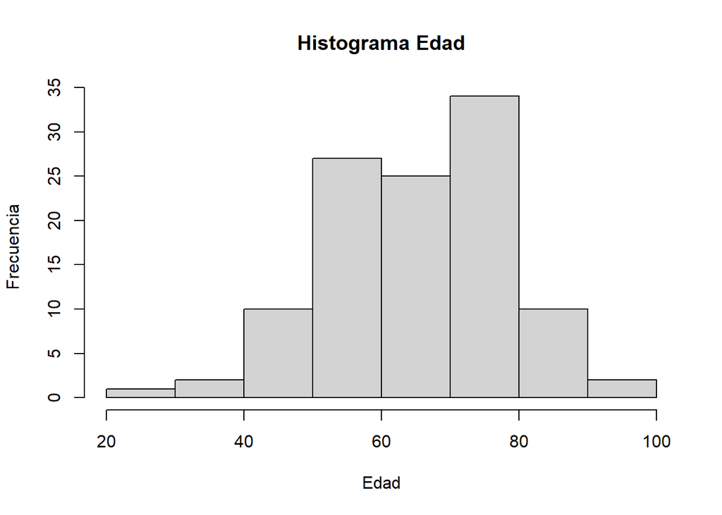

### Gráfico de densidad edad, Comuna de Calama

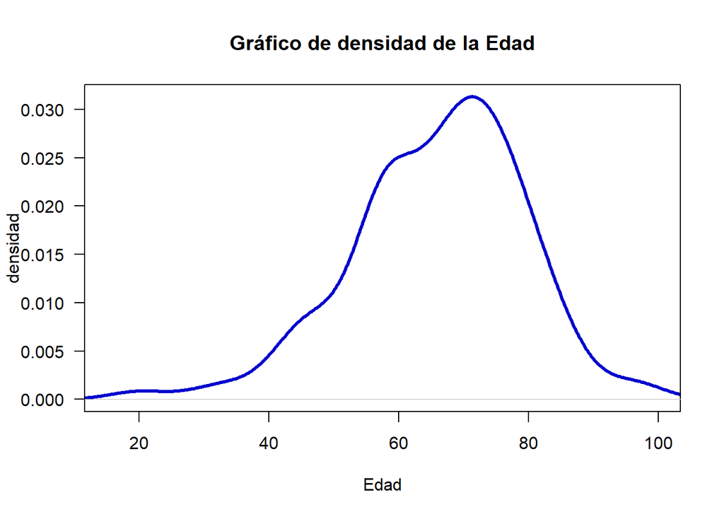

### Normal QQ, Comuna de Calama

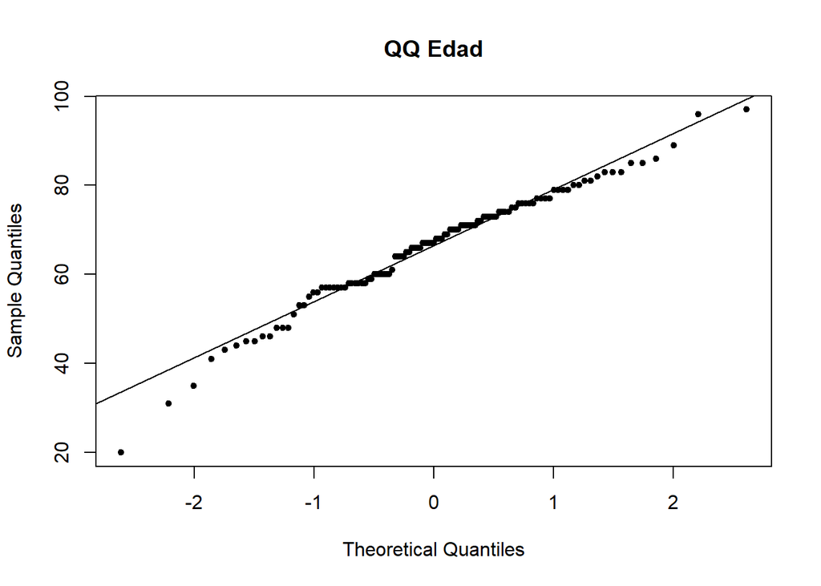

### Test de normalidad de Shapiro-Wilk, Comuna de Calama

```
##
##  Shapiro-Wilk normality test
##
## data:  bd_2$EDAD
## W = 0.97626, p-value = 0.04491
```

## Estadística descriptiva Bivariada, comuna de Calama

### Número de casos por sexo y morfología, comuna de Calama

```
##
##                                        Hombres Mujeres Sum
##   Neoplasias, SAI                           15      10  25
##   Carcinomas de células transicionales      54      16  70
##   Otras morfologías                         12       4  16
##   Sum                                       81      30 111
```

### Proporción de casos por sexo y morfología, comuna de Calama

```
##
##                                        Hombres Mujeres    Sum
##   Neoplasias, SAI                        60.00   40.00 100.00
##   Carcinomas de células transicionales   77.14   22.86 100.00
##   Otras morfologías                      75.00   25.00 100.00
```

### Número de casos por sexo y extensión tumoral, comuna de Calama

```
##
##               Hombres Mujeres Sum
##   Localizado       54      19  73
##   Regional          5       3   8
##   Metástasis       12       5  17
##   Desconocido      10       3  13
##   Sum              81      30 111
```

### Proporción de casos por sexo y extensión tumoral, Comuna de Calama

```
##
##               Hombres Mujeres    Sum
##   Localizado    73.97   26.03 100.00
##   Regional      62.50   37.50 100.00
##   Metástasis    70.59   29.41 100.00
##   Desconocido   76.92   23.08 100.00
```

### Número de casos por sexo y base diagnóstica, comuna de Calama

```
##
##                                Hombres Mujeres Sum
##   Solo DCO                           6       4  10
##   Clínico                            1       2   3
##   Investigación Clínica              6       4  10
##   Histología de Metástasis           1       1   2
##   Histología de sitio primario      67      19  86
##   Sum                               81      30 111
```

### Proporción de casos por sexo y base diagnóstica, comuna de Calama

```
##
##                                Hombres Mujeres    Sum
##   Solo DCO                       60.00   40.00 100.00
##   Clínico                        33.33   66.67 100.00
##   Investigación Clínica          60.00   40.00 100.00
##   Histología de Metástasis       50.00   50.00 100.00
##   Histología de sitio primario   77.91   22.09 100.00
```

### Número de casos por Morfología y base diagnóstica, comuna de Calama

```
##
##                                        Solo DCO Clínico Investigación Clínica
##   Neoplasias, SAI                            10       3                    10
##   Carcinomas de células transicionales        0       0                     0
##   Otras morfologías                           0       0                     0
##   Sum                                        10       3                    10
##
##                                        Histología de Metástasis
##   Neoplasias, SAI                                             0
##   Carcinomas de células transicionales                        1
##   Otras morfologías                                           1
##   Sum                                                         2
##
##                                        Histología de sitio primario Sum
##   Neoplasias, SAI                                                 2  25
##   Carcinomas de células transicionales                           69  70
##   Otras morfologías                                              15  16
##   Sum                                                            86 111
```

### Proporción de casos por Morfología y base diagnóstica, comuna de Calama

```
##
##                                        Solo DCO Clínico Investigación Clínica
##   Neoplasias, SAI                         40.00   12.00                 40.00
##   Carcinomas de células transicionales     0.00    0.00                  0.00
##   Otras morfologías                        0.00    0.00                  0.00
##
##                                        Histología de Metástasis
##   Neoplasias, SAI                                          0.00
##   Carcinomas de células transicionales                     1.43
##   Otras morfologías                                        6.25
##
##                                        Histología de sitio primario    Sum
##   Neoplasias, SAI                                              8.00 100.00
##   Carcinomas de células transicionales                        98.57 100.00
##   Otras morfologías                                           93.75 100.00
```

### Número de casos por Morfología y Extensión, comuna de Calama

```
##
##                                      Localizado Regional Metástasis Desconocido
##   Neoplasias, SAI                             5        1         10           9
##   Carcinoma de células transcionales         59        4          4           3
##   Otras morfologías                           9        3          3           1
##   Sum                                        73        8         17          13
##
##                                      Sum
##   Neoplasias, SAI                     25
##   Carcinoma de células transcionales  70
##   Otras morfologías                   16
##   Sum                                111
```

### Proporción de casos por Morfología y Extensión, comuna de Calama

```
##
##                                      Localizado Regional Metástasis Desconocido
##   Neoplasias, SAI                         20.00     4.00      40.00       36.00
##   Carcinoma de células transcionales      84.29     5.71       5.71        4.29
##   Otras morfologías                       56.25    18.75      18.75        6.25
##
##                                         Sum
##   Neoplasias, SAI                    100.00
##   Carcinoma de células transcionales 100.00
##   Otras morfologías                  100.00
```

### Número de casos por Extensión y Base diagnóstica, comuna de Calama

```
##
##               Solo DCO Clínico Investigación Clínica Histología de Metástasis
##   Localizado         1       3                     0                        1
##   Regional           0       0                     1                        0
##   Metástasis         0       0                     9                        1
##   Desconocido        9       0                     0                        0
##   Sum               10       3                    10                        2
##
##               Histología de sitio primario Sum
##   Localizado                            68  73
##   Regional                               7   8
##   Metástasis                             7  17
##   Desconocido                            4  13
##   Sum                                   86 111
```

### Proporción de casos por Extensión y Base diagnóstica, filas, comuna de Calama

```
##
##               Solo DCO Clínico Investigación Clínica Histología de Metástasis
##   Localizado      1.37    4.11                  0.00                     1.37
##   Regional        0.00    0.00                 12.50                     0.00
##   Metástasis      0.00    0.00                 52.94                     5.88
##   Desconocido    69.23    0.00                  0.00                     0.00
##
##               Histología de sitio primario    Sum
##   Localizado                         93.15 100.00
##   Regional                           87.50 100.00
##   Metástasis                         41.18 100.00
##   Desconocido                        30.77 100.00
```

### Proporción de casos por Extensión y Base diagnóstica, columnas, Comuna de Calama

```
##
##               Solo DCO Clínico Investigación Clínica Histología de Metástasis
##   Localizado     10.00  100.00                  0.00                    50.00
##   Regional        0.00    0.00                 10.00                     0.00
##   Metástasis      0.00    0.00                 90.00                    50.00
##   Desconocido    90.00    0.00                  0.00                     0.00
##   Sum           100.00  100.00                100.00                   100.00
##
##               Histología de sitio primario
##   Localizado                         79.07
##   Regional                            8.14
##   Metástasis                          8.14
##   Desconocido                         4.65
##   Sum                               100.00
```

### Edad - Sexo

#### Boxplot edad vs sexo, Comuna de Calama

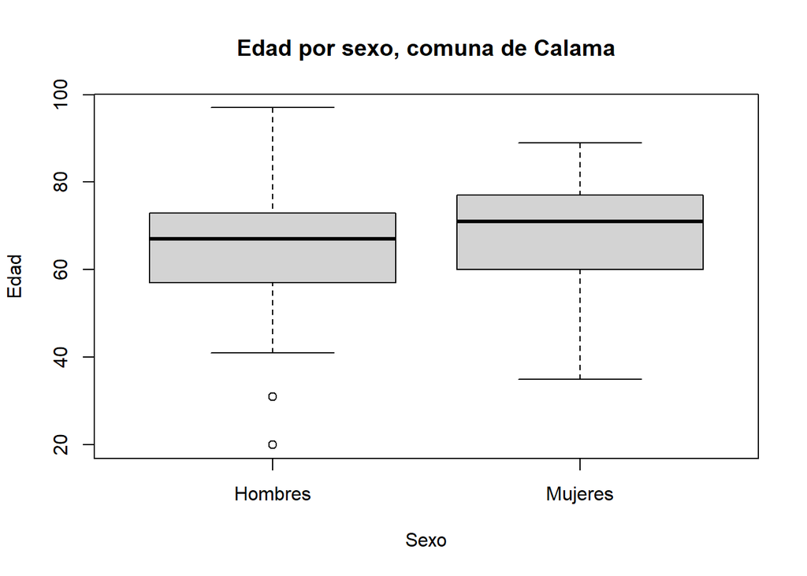

### Boxplot edad - morfologia, Comuna de Calama

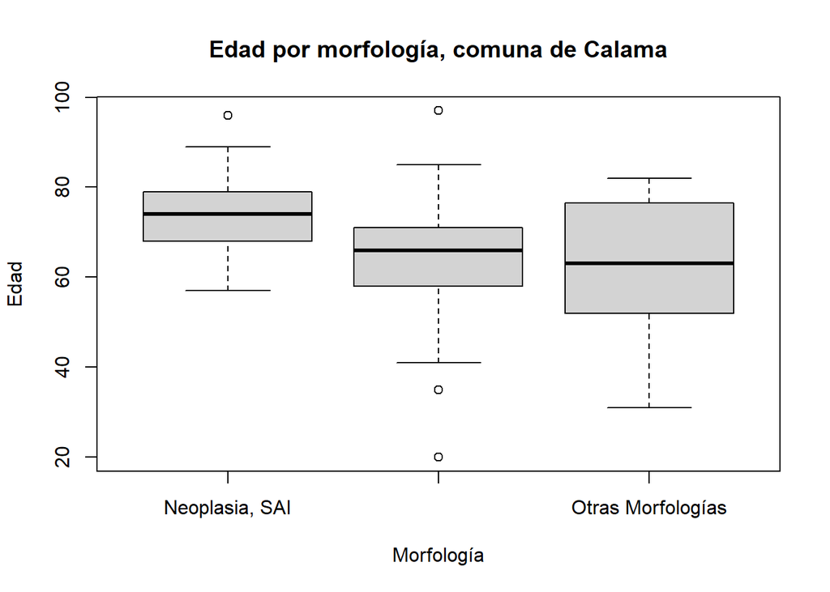

### Boxplot edad - extension, Comuna de Calama

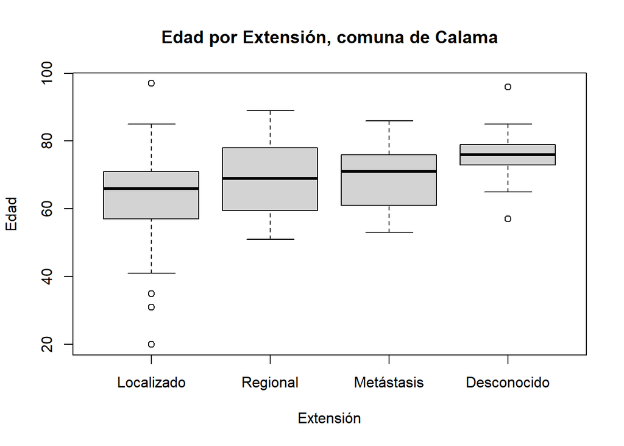

### Boxplot edad - base diagnóstica, Comuna de Calama

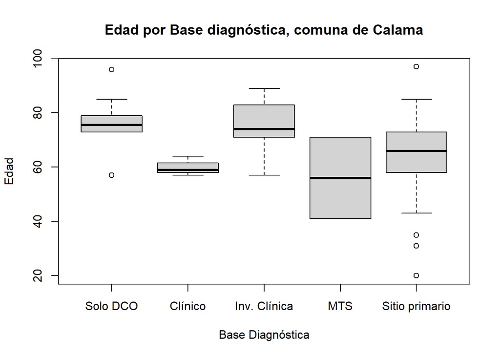

## Tasa de incidencia ajustada por año, Comuna de Calama

| YEAR_DIAG | TASA_AJUSTADA |
| --- | --- |
| 2003 | 3.134796 |
| 2004 | 7.165387 |
| 2005 | 2.472730 |
| 2006 | 10.061460 |
| 2007 | 5.434809 |
| 2008 | 7.161748 |
| 2009 | 8.657670 |
| 2010 | 7.473903 |
| 2011 | 5.694994 |
| 2012 | 7.277588 |

[output cut: 3 more lines]

[figure not shown]

## Tasa de incidencia ajustada por edad y sexo, según año. Comuna de Calama

| YEAR_DIAG | TASA_AJUSTADA | STD_ERROR |
| --- | --- | --- |
| 2003 | 3.134796 | 1.8098755 |
| 2004 | 4.419022 | 2.2142847 |
| 2005 | 1.771959 | 1.3087971 |
| 2006 | 7.352306 | 2.3661701 |
| 2007 | 2.817954 | 1.6450306 |
| 2008 | 6.515336 | 2.2523459 |
| 2009 | 6.023008 | 2.0608866 |
| 2010 | 3.071656 | 1.5726536 |
| 2011 | 4.360970 | 1.9535296 |
| 2012 | 6.147760 | 1.9877446 |

[output cut: 3 more lines]

| YEAR_DIAG | TASA_AJUSTADA | STD_ERROR |
| --- | --- | --- |
| 2004 | 2.7463655 | 1.5996938 |
| 2005 | 0.7007708 | 0.7007708 |
| 2006 | 2.7091538 | 1.5903272 |
| 2007 | 2.6168547 | 1.5411805 |
| 2008 | 0.6464124 | 0.6464124 |
| 2009 | 2.6346622 | 1.5472029 |
| 2010 | 4.4022462 | 1.8163758 |
| 2011 | 1.3340242 | 0.9882084 |
| 2012 | 1.1298278 | 0.8063625 |
| 2013 | 1.1345888 | 0.8068177 |

[output cut: 2 more lines]

### Gráfico de la tasa de incidencia de cáncer de Vejiga, ajustada por edad y sexo en la comuna de Calama.

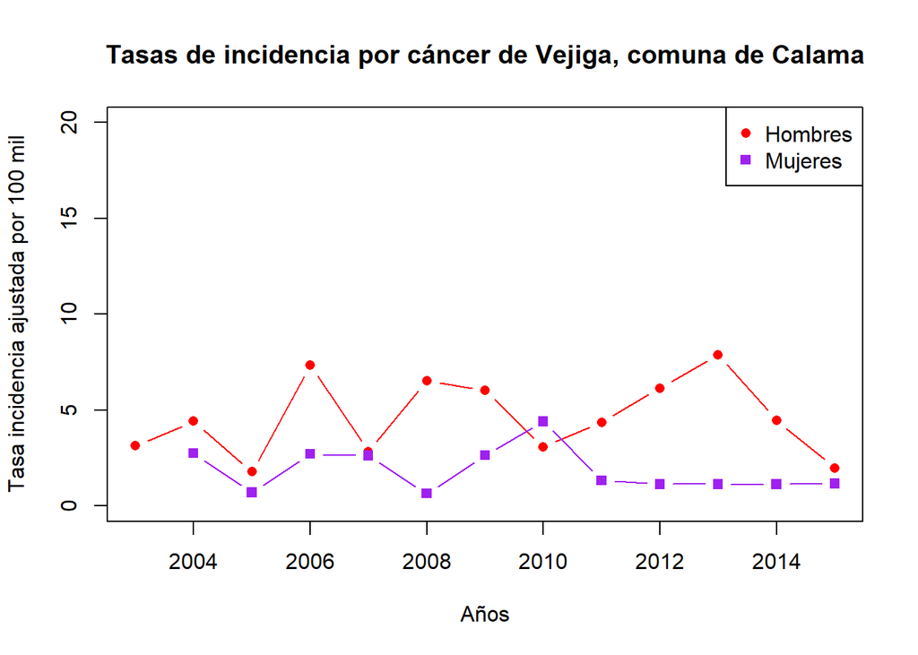

# Comuna de Tocopilla

### Número de casos por sexo, Comuna de Tocopilla

```
##
## Hombres Mujeres
##      45      30
```

### Proporción de casos por sexo, comuna de Tocopilla

```
##
## Hombres Mujeres
##      60      40
```

### Casos según morfología, comuna de Tocopilla

```
##
##                      Neoplasias, SAI Carcinomas de células transicionales
##                                   20                                   53
##                    Otras Morfologías
##                                    2
```

### Proporción de casos según morfología, comuna de Tocopilla

```
##
##                      Neoplasias, SAI Carcinomas de células transicionales
##                                 26.7                                 70.7
##                    Otras Morfologías
##                                  2.7
```

### Casos según diferenciacion tumores, comuna de Tocopilla

```
##
##           Bien Diferenciado Moderadamente Diferenciados
##                           6                           1
##           Poco Diferenciado                  Anaplásico
##                          17                           1
##                 Desconocido
##                          50
```

### Proporción de casos según diferenciación, Comuna de Tocopilla

```
##
##           Bien Diferenciado Moderadamente Diferenciados
##                        8.00                        1.33
##           Poco Diferenciado                  Anaplásico
##                       22.67                        1.33
##                 Desconocido
##                       66.67
```

### Casos según extensión tumoral, Comuna de Tocopilla

```
##
##  Localizado    Regional  Metástasis Desconocido
##          50           3           8          14
```

### Proporción de casos según extensión tumoral, Comuna de Tocopilla

```
##
##  Localizado    Regional  Metástasis Desconocido
##       66.67        4.00       10.67       18.67
```

### Casos según base diagnóstico, Comuna de Tocopilla

```
##
##                     Solo DCO                      Clínica
##                            9                            4
##        Investigación Clínica            Histología de MTS
##                            7                            1
## Histología de sitio primario
##                           54
```

### Proporción de casos según base diagnóstico, Comuna de Tocopilla

```
##
##                     Solo DCO                      Clínica
##                        12.00                         5.33
##        Investigación Clínica            Histología de MTS
##                         9.33                         1.33
## Histología de sitio primario
##                        72.00
```

## Estadística descriptiva univariada cuantitativa, Vejiga. Comuna de Tocopilla

### Edad, Comuna de Tocopilla

| Mínimo | Máximo | Rango | Qu_25 | Qu_50 | Qu_75 | Media | Mediana | Varianza | Desv_Estándar | CV |
| --- | --- | --- | --- | --- | --- | --- | --- | --- | --- | --- |
| 42 | 92 | 50 | 61 | 70 | 78 | 68.6533 | 70 | 129.635 | 11.3857 | 16.5844 |

### Histrograma edad, Comuna de Tocopilla

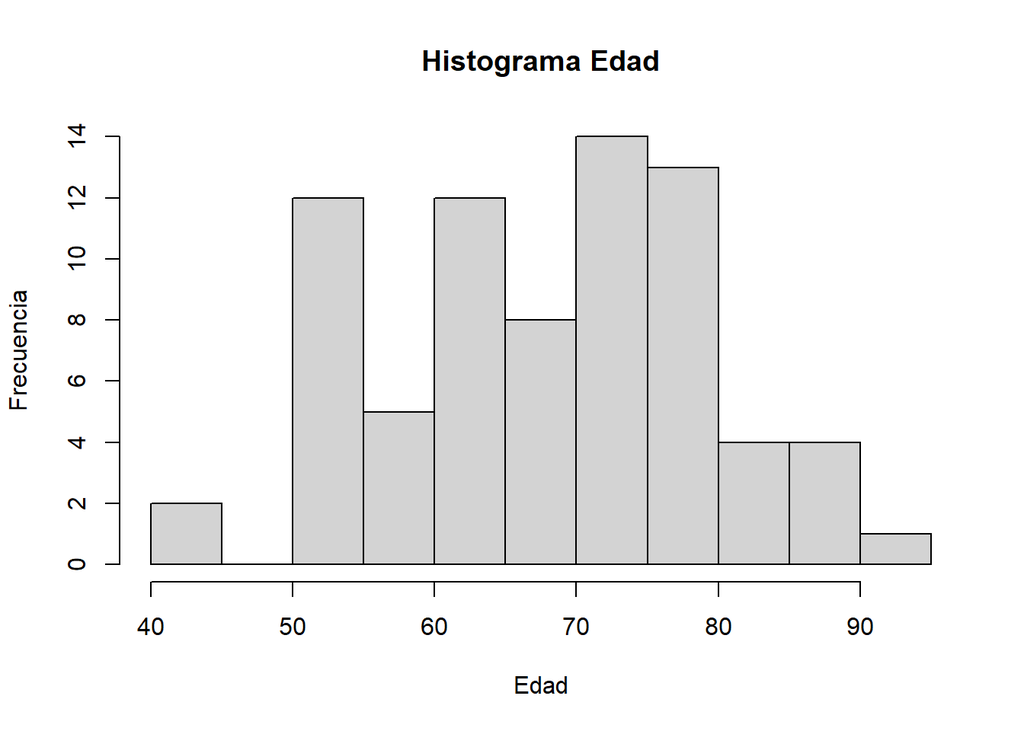

### Gráfico de densidad edad, Comuna de Tocopilla

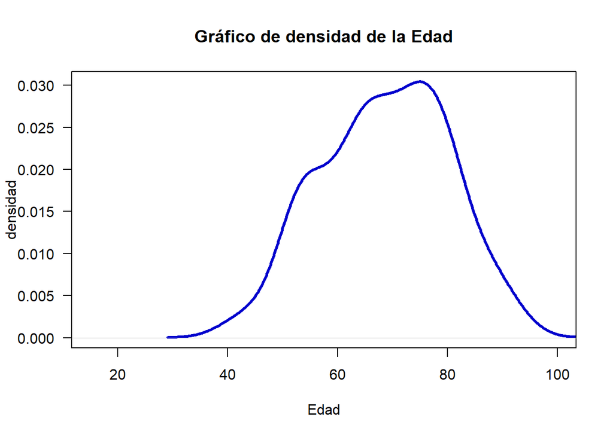

### Normal QQ, Comuna de Tocopilla

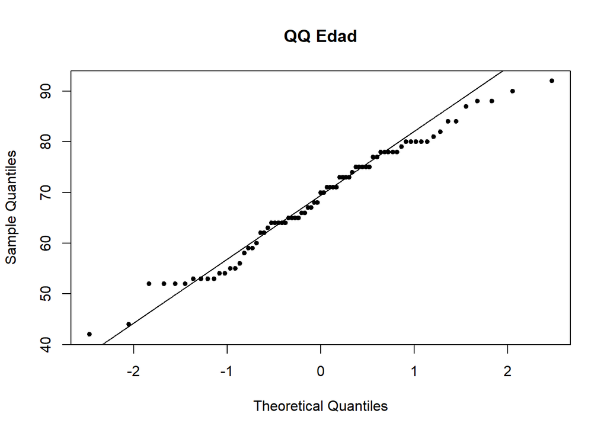

### Test de normalidad de Shapiro-Wilk, Comuna de Tocopilla

```
##
##  Shapiro-Wilk normality test
##
## data:  bd_3$EDAD
## W = 0.97939, p-value = 0.2603
```

## Estadística descriptiva Bivariada, comuna de Tocopilla

### Número de casos por sexo y morfología, comuna de Tocopilla

```
##
##                                        Hombres Mujeres Sum
##   Neoplasias, SAI                           10      10  20
##   Carcinomas de células transicionales      34      19  53
##   Otras morfologías                          1       1   2
##   Sum                                       45      30  75
```

### Proporción de casos por sexo y morfología, comuna de Tocopilla

```
##
##                                        Hombres Mujeres    Sum
##   Neoplasias, SAI                        50.00   50.00 100.00
##   Carcinomas de células transicionales   64.15   35.85 100.00
##   Otras morfologías                      50.00   50.00 100.00
```

### Número de casos por sexo y extensión tumoral, comuna de Tocopilla

```
##
##               Hombres Mujeres Sum
##   Localizado       31      19  50
##   Regional          3       0   3
##   Metástasis        4       4   8
##   Desconocido       7       7  14
##   Sum              45      30  75
```

### Proporción de casos por sexo y extensión tumoral, Comuna de Tocopilla

```
##
##               Hombres Mujeres Sum
##   Localizado       62      38 100
##   Regional        100       0 100
##   Metástasis       50      50 100
##   Desconocido      50      50 100
```

### Número de casos por sexo y base diagnóstica, comuna de Tocopilla

```
##
##                                Hombres Mujeres Sum
##   Solo DCO                           4       5   9
##   Clínico                            2       2   4
##   Investigación Clínica              4       3   7
##   Histología de Metástasis           0       1   1
##   Histología de sitio primario      35      19  54
##   Sum                               45      30  75
```

### Proporción de casos por sexo y base diagnóstica, comuna de Tocopilla

```
##
##                                Hombres Mujeres    Sum
##   Solo DCO                       44.44   55.56 100.00
##   Clínico                        50.00   50.00 100.00
##   Investigación Clínica          57.14   42.86 100.00
##   Histología de Metástasis        0.00  100.00 100.00
##   Histología de sitio primario   64.81   35.19 100.00
```

### Número de casos por Morfología y base diagnóstica, comuna de Tocopilla

```
##
##                                          Solo DCO Clínico Investigación Clínica
##   Neoplasias, SAI                               9       4                     7
##   Carcinomas de células intraepiteliales        0       0                     0
##   Otras morfologías                             0       0                     0
##   Sum                                           9       4                     7
##
##                                          Histología de Metástasis
##   Neoplasias, SAI                                               0
##   Carcinomas de células intraepiteliales                        0
##   Otras morfologías                                             1
##   Sum                                                           1
##
##                                          Histología de sitio primario Sum
##   Neoplasias, SAI                                                   0  20
##   Carcinomas de células intraepiteliales                           53  53
##   Otras morfologías                                                 1   2
##   Sum                                                              54  75
```

### Proporción de casos por Morfología y base diagnóstica, comuna de Tocopilla

```
##
##                                          Solo DCO Clínico Investigación Clínica
##   Neoplasias, SAI                              45      20                    35
##   Carcinomas de células intraepiteliales        0       0                     0
##   Otras morfologías                             0       0                     0
##
##                                          Histología de Metástasis
##   Neoplasias, SAI                                               0
##   Carcinomas de células intraepiteliales                        0
##   Otras morfologías                                            50
##
##                                          Histología de sitio primario Sum
##   Neoplasias, SAI                                                   0 100
##   Carcinomas de células intraepiteliales                          100 100
##   Otras morfologías                                                50 100
```

### Número de casos por Morfología y Extensión, comuna de Tocopilla

```
##
##                                       Localizado Regional Metástasis
##   Neoplasias, SAI                              3        0          4
##   Carcinomas de células transcionales         46        3          3
##   Otras morfologías                            1        0          1
##   Sum                                         50        3          8
##
##                                       Desconocido Sum
##   Neoplasias, SAI                              13  20
##   Carcinomas de células transcionales           1  53
##   Otras morfologías                             0   2
##   Sum                                          14  75
```

### Proporción de casos por Morfología y Extensión, comuna de Tocopilla

```
##
##                                       Localizado Regional Metástasis
##   Neoplasias, SAI                          15.00     0.00      20.00
##   Carcinomas de células transcionales      86.79     5.66       5.66
##   Otras morfologías                        50.00     0.00      50.00
##
##                                       Desconocido    Sum
##   Neoplasias, SAI                           65.00 100.00
##   Carcinomas de células transcionales        1.89 100.00
##   Otras morfologías                          0.00 100.00
```

### Número de casos por Extensión y Base diagnóstica, comuna de Tocopilla

```
##
##               Solo DCO Clínico Investigación Clínica Histología de Metástasis
##   Localizado         0       2                     1                        0
##   Regional           0       0                     0                        0
##   Metástasis         0       0                     4                        1
##   Desconocido        9       2                     2                        0
##   Sum                9       4                     7                        1
##
##               Histología de sitio primario Sum
##   Localizado                            47  50
##   Regional                               3   3
##   Metástasis                             3   8
##   Desconocido                            1  14
##   Sum                                   54  75
```

### Proporción de casos por Extensión y Base diagnóstica, filas, comuna de Tocopilla

```
##
##               Solo DCO Clínico Investigación Clínica Histología de Metástasis
##   Localizado      0.00    4.00                  2.00                     0.00
##   Regional        0.00    0.00                  0.00                     0.00
##   Metástasis      0.00    0.00                 50.00                    12.50
##   Desconocido    64.29   14.29                 14.29                     0.00
##
##               Histología de sitio primario    Sum
##   Localizado                         94.00 100.00
##   Regional                          100.00 100.00
##   Metástasis                         37.50 100.00
##   Desconocido                         7.14 100.00
```

### Proporción de casos por Extensión y Base diagnóstica, columnas, Comuna de Tocopilla

```
##
##               Solo DCO Clínico Investigación Clínica Histología de Metástasis
##   Localizado      0.00   50.00                 14.29                     0.00
##   Regional        0.00    0.00                  0.00                     0.00
##   Metástasis      0.00    0.00                 57.14                   100.00
##   Desconocido   100.00   50.00                 28.57                     0.00
##   Sum           100.00  100.00                100.00                   100.00
##
##               Histología de sitio primario
##   Localizado                         87.04
##   Regional                            5.56
##   Metástasis                          5.56
##   Desconocido                         1.85
##   Sum                               100.00
```

### Edad - Sexo

#### Boxplot edad vs sexo, Comuna de Tocopilla

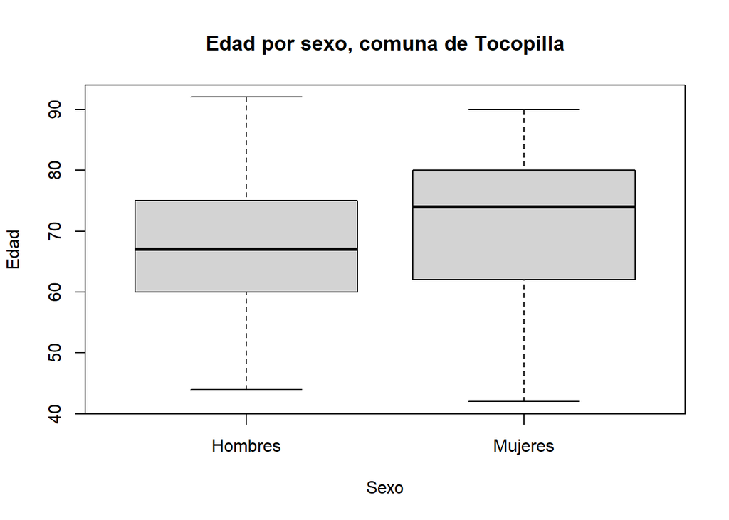

### Boxplot edad - morfologia, Comuna de Tocopilla

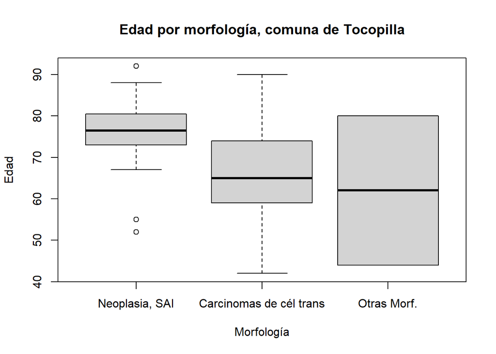

### Boxplot edad - extension, Comuna de Tocopilla

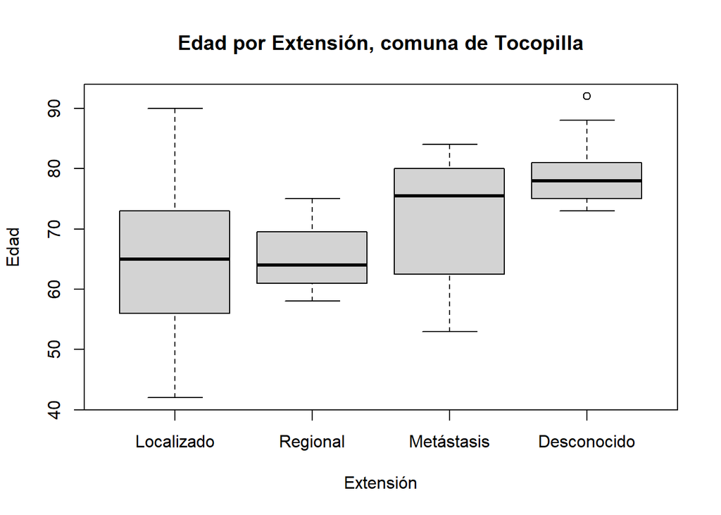

### Boxplot edad - base diagnóstica, Comuna de Tocopilla

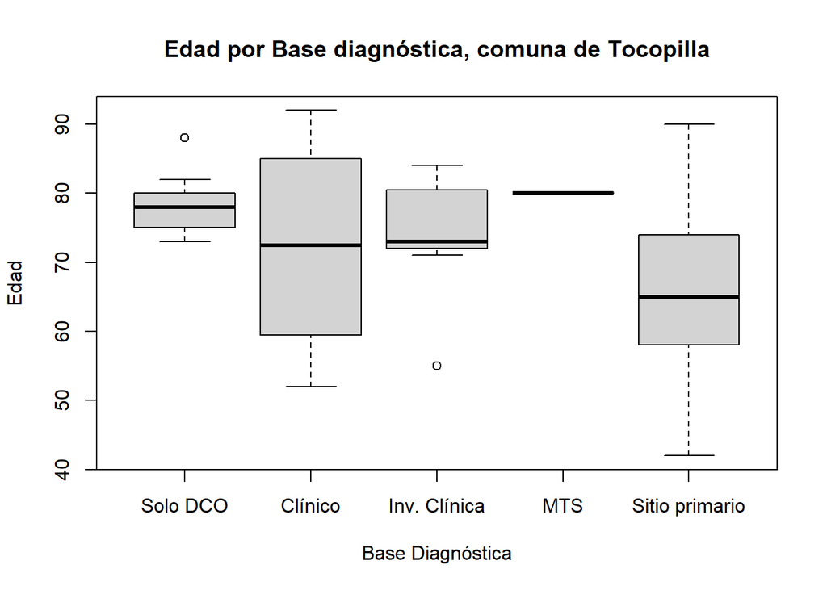

## Tasa de incidencia ajustada por año, Comuna de Tocopilla

| YEAR_DIAG | TASA_AJUSTADA |
| --- | --- |
| 2003 | 14.97496 |
| 2004 | 27.25848 |
| 2005 | 10.97763 |
| 2006 | 22.04425 |
| 2007 | 16.79824 |
| 2008 | 25.62616 |
| 2009 | 27.71894 |
| 2010 | 13.69615 |
| 2011 | 16.64734 |
| 2012 | 11.03877 |

[output cut: 3 more lines]

### Gráfico de la tasa de incidencia de cáncer de vejiga, ajustada por edad en Comuna de Tocopilla

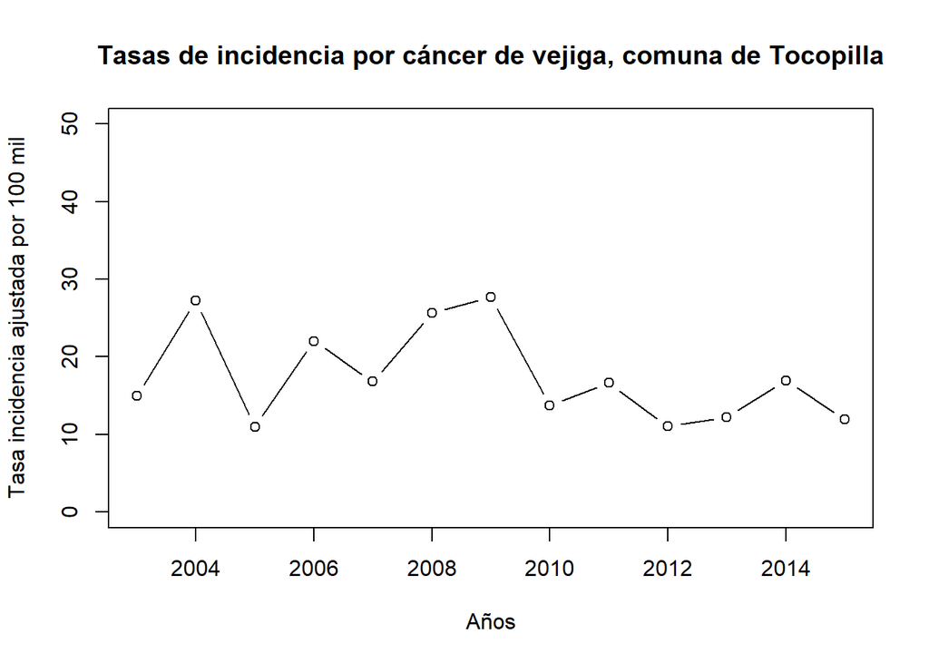

## Tasa de incidencia ajustada por edad y sexo, según año. Comuna de Tocopilla

| YEAR_DIAG | TASA_AJUSTADA | STD_ERROR |
| --- | --- | --- |
| 2003 | 11.510761 | 6.895143 |
| 2004 | 14.132254 | 7.125083 |
| 2005 | 3.476246 | 3.476246 |
| 2006 | 9.562915 | 5.706339 |
| 2007 | 16.798245 | 7.684867 |
| 2008 | 23.484828 | 9.001139 |
| 2009 | 16.244484 | 7.533044 |
| 2010 | 5.874976 | 4.358949 |
| 2011 | 8.689959 | 5.074951 |
| 2012 | 5.519384 | 3.958071 |

[output cut: 3 more lines]

| YEAR_DIAG | TASA_AJUSTADA | STD_ERROR |
| --- | --- | --- |
| 2003 | 3.464203 | 3.464203 |
| 2004 | 13.126231 | 6.581097 |
| 2005 | 7.501381 | 5.343486 |
| 2006 | 12.481336 | 6.469315 |
| 2008 | 2.141328 | 2.141328 |
| 2009 | 11.474456 | 5.939030 |
| 2010 | 7.821171 | 4.751026 |
| 2011 | 7.957383 | 4.804063 |
| 2012 | 5.519384 | 3.958071 |
| 2013 | 3.184713 | 3.184713 |

[output cut: 2 more lines]

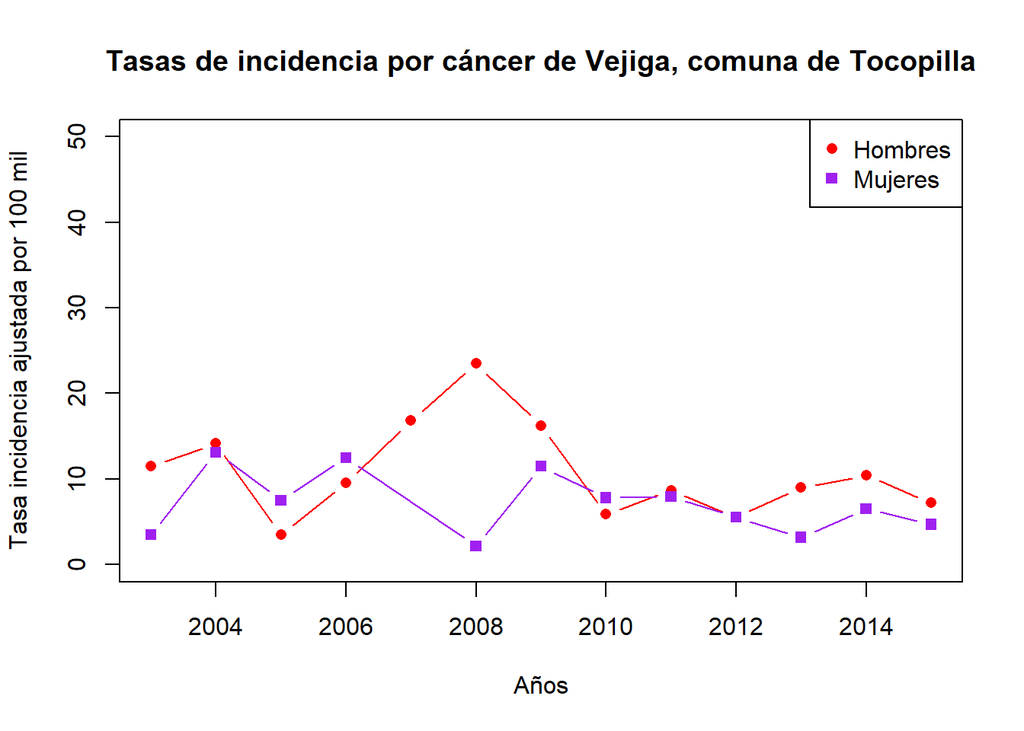

# Plot tasas de incidencia por cáncer de Vejiga

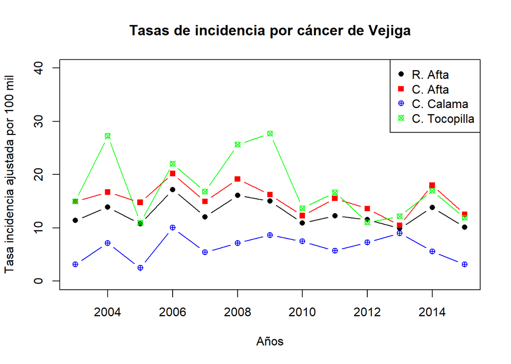